# Lab 2 | Gathering & Cleaning Data

Welcome to Lab 2! This lab is about dealing with the Titanic dataset. For background information, the Titanic was a passenger ship that famously sank in 1912, with an estimated 1,500 people lost in the wreck.

### About the Dataset

The dataset contains demographic information about passengers who were on board the Titanic as well as whether they survived or not. We focus on loading the data, building an understanding of the dataset, and cleaning the data for later use.

## Section 1 | Reading the Data using Pandas & Manually

To start off, we need to access the dataset. The dataset is in a `.csv` format, and is assumed to be in the same directory as this Jupyter notebook. In the cells below, we access the `.csv` file using Pandas first.

```python
# importing the pandas library
import pandas as pd

# importing the seaborn library
import seaborn as sns

# importing the matplotlib library
import matplotlib.pyplot as plt

# importing the csv library
import csv

# importing the IPython library
from IPython.display import display
```

```python
# reading the .csv file
titanic_df = pd.read_csv('titanic.csv')

# viewing the first 5 rows of the data frame
display(titanic_df.head(5))

# viewing the information of the data frame
titanic_df.info()

# viewing the description of the data frame
titanic_df.describe()
```

|  | PassengerId | Survived | Pclass | Name | Sex | Age | SibSp | Parch | Ticket | Fare | Cabin | Embarked |
| --- | --- | --- | --- | --- | --- | --- | --- | --- | --- | --- | --- | --- |
| 0 | 1 | 0 | 3 | Braund, Mr. Owen Harris | male | 22.0 | 1 | 0 | A/5 21171 | 7.2500 | NaN | S |
| 1 | 2 | 1 | 1 | Cumings, Mrs. John Bradley (Florence Briggs Th... | female | 38.0 | 1 | 0 | PC 17599 | 71.2833 | C85 | C |
| 2 | 3 | 1 | 3 | Heikkinen, Miss. Laina | female | 26.0 | 0 | 0 | STON/O2. 3101282 | 7.9250 | NaN | S |
| 3 | 4 | 1 | 1 | Futrelle, Mrs. Jacques Heath (Lily May Peel) | female | 35.0 | 1 | 0 | 113803 | 53.1000 | C123 | S |
| 4 | 5 | 0 | 3 | Allen, Mr. William Henry | male | 35.0 | 0 | 0 | 373450 | 8.0500 | NaN | S |

```
<class 'pandas.core.frame.DataFrame'>
RangeIndex: 891 entries, 0 to 890
Data columns (total 12 columns):
 #   Column       Non-Null Count  Dtype
---  ------       --------------  -----
 0   PassengerId  891 non-null    int64
 1   Survived     891 non-null    int64
 2   Pclass       891 non-null    int64
 3   Name         891 non-null    object
 4   Sex          891 non-null    object
 5   Age          714 non-null    float64
 6   SibSp        891 non-null    int64
 7   Parch        891 non-null    int64
 8   Ticket       891 non-null    object
 9   Fare         891 non-null    float64
 10  Cabin        204 non-null    object
 11  Embarked     889 non-null    object
dtypes: float64(2), int64(5), object(5)
memory usage: 83.7+ KB
```

|  | PassengerId | Survived | Pclass | Age | SibSp | Parch | Fare |
| --- | --- | --- | --- | --- | --- | --- | --- |
| count | 891.000000 | 891.000000 | 891.000000 | 714.000000 | 891.000000 | 891.000000 | 891.000000 |
| mean | 446.000000 | 0.383838 | 2.308642 | 29.699118 | 0.523008 | 0.381594 | 32.204208 |
| std | 257.353842 | 0.486592 | 0.836071 | 14.526497 | 1.102743 | 0.806057 | 49.693429 |
| min | 1.000000 | 0.000000 | 1.000000 | 0.420000 | 0.000000 | 0.000000 | 0.000000 |
| 25% | 223.500000 | 0.000000 | 2.000000 | 20.125000 | 0.000000 | 0.000000 | 7.910400 |
| 50% | 446.000000 | 0.000000 | 3.000000 | 28.000000 | 0.000000 | 0.000000 | 14.454200 |
| 75% | 668.500000 | 1.000000 | 3.000000 | 38.000000 | 1.000000 | 0.000000 | 31.000000 |
| max | 891.000000 | 1.000000 | 3.000000 | 80.000000 | 8.000000 | 6.000000 | 512.329200 |

Great! Now that we've accessed the `.csv` file using pandas, we can now try to acces the file manually using basic Python. We attempt this by reading the data into a dictionary where the **keys** are variable names and the **values** are lists.

```python
# initializing a dictionary
data_dictionary = {}

# extracting the keys from the dictionary
with open('titanic.csv') as file:
    first_line = file.readline().strip().split(",")

# allowing each key to have a empty list
data_dictionary = {key: [] for key in first_line}

# printing out the keys to check if done right
print("List of Keys: ", first_line, "\n")

# checking if the keys are added
print("Dictionary Keys: ", data_dictionary.keys())
```

```
List of Keys:  ['PassengerId', 'Survived', 'Pclass', 'Name', 'Sex', 'Age', 'SibSp', 'Parch', 'Ticket', 'Fare', 'Cabin', 'Embarked']

Dictionary Keys:  dict_keys(['PassengerId', 'Survived', 'Pclass', 'Name', 'Sex', 'Age', 'SibSp', 'Parch', 'Ticket', 'Fare', 'Cabin', 'Embarked'])
```

Cool! Now that we have set up the keys for the dictionary, we would like to **add** in the values. We achieve this by creating a list from each line and then **adding** them to each key using a for loop. We then **print** out the details of the dictionary to check if everything went right.

```python
# opening the titanic csv file
with open('titanic.csv') as file:

        # using the csv reader to read the file
        reader = csv.reader(file)

        # skipping the keys
        next(reader)

        for line in reader:
            # appending each value to each key
            for key, value in zip(data_dictionary.keys(), line):
                data_dictionary[key].append(value)

# setting up a test string
test_string = ""

# printing out the key and values of the dictionary
for key, value in data_dictionary.items():
    test_string += key + " "

    for val in value:
        test_string += val + " "

    test_string += "\n"

# printing out the test string
print(test_string)
```

[output not shown]

Now that we've manually created a dictionary, we will now convert the `data_dictionary` into a Pandas Dataframe.

```python
# converting the dictionary into a data frame
data_dictionary_df = pd.DataFrame(data_dictionary)

# displaying the data frame
data_dictionary_df
```

|  | PassengerId | Survived | Pclass | Name | Sex | Age | SibSp | Parch | Ticket | Fare | Cabin | Embarked |
| --- | --- | --- | --- | --- | --- | --- | --- | --- | --- | --- | --- | --- |
| 0 | 1 | 0 | 3 | Braund, Mr. Owen Harris | male | 22 | 1 | 0 | A/5 21171 | 7.25 |  | S |
| 1 | 2 | 1 | 1 | Cumings, Mrs. John Bradley (Florence Briggs Th... | female | 38 | 1 | 0 | PC 17599 | 71.2833 | C85 | C |
| 2 | 3 | 1 | 3 | Heikkinen, Miss. Laina | female | 26 | 0 | 0 | STON/O2. 3101282 | 7.925 |  | S |
| 3 | 4 | 1 | 1 | Futrelle, Mrs. Jacques Heath (Lily May Peel) | female | 35 | 1 | 0 | 113803 | 53.1 | C123 | S |
| 4 | 5 | 0 | 3 | Allen, Mr. William Henry | male | 35 | 0 | 0 | 373450 | 8.05 |  | S |
| ... | ... | ... | ... | ... | ... | ... | ... | ... | ... | ... | ... | ... |
| 886 | 887 | 0 | 2 | Montvila, Rev. Juozas | male | 27 | 0 | 0 | 211536 | 13 |  | S |
| 887 | 888 | 1 | 1 | Graham, Miss. Margaret Edith | female | 19 | 0 | 0 | 112053 | 30 | B42 | S |
| 888 | 889 | 0 | 3 | Johnston, Miss. Catherine Helen "Carrie" | female |  | 1 | 2 | W./C. 6607 | 23.45 |  | S |
| 889 | 890 | 1 | 1 | Behr, Mr. Karl Howell | male | 26 | 0 | 0 | 111369 | 30 | C148 | C |
| 890 | 891 | 0 | 3 | Dooley, Mr. Patrick | male | 32 | 0 | 0 | 370376 | 7.75 |  | Q |

891 rows × 12 columns

```python
# displaying the info
display(data_dictionary_df.info())

# describing the data frame
display(data_dictionary_df.describe())
```

```
<class 'pandas.core.frame.DataFrame'>
RangeIndex: 891 entries, 0 to 890
Data columns (total 12 columns):
 #   Column       Non-Null Count  Dtype
---  ------       --------------  -----
 0   PassengerId  891 non-null    object
 1   Survived     891 non-null    object
 2   Pclass       891 non-null    object
 3   Name         891 non-null    object
 4   Sex          891 non-null    object
 5   Age          891 non-null    object
 6   SibSp        891 non-null    object
 7   Parch        891 non-null    object
 8   Ticket       891 non-null    object
 9   Fare         891 non-null    object
 10  Cabin        891 non-null    object
 11  Embarked     891 non-null    object
dtypes: object(12)
memory usage: 83.7+ KB
```

```
None
```

|  | PassengerId | Survived | Pclass | Name | Sex | Age | SibSp | Parch | Ticket | Fare | Cabin | Embarked |
| --- | --- | --- | --- | --- | --- | --- | --- | --- | --- | --- | --- | --- |
| count | 891 | 891 | 891 | 891 | 891 | 891 | 891 | 891 | 891 | 891 | 891 | 891 |
| unique | 891 | 2 | 3 | 891 | 2 | 89 | 7 | 7 | 681 | 248 | 148 | 4 |
| top | 891 | 0 | 3 | Dooley, Mr. Patrick | male |  | 0 | 0 | 347082 | 8.05 |  | S |
| freq | 1 | 549 | 491 | 1 | 577 | 177 | 608 | 678 | 7 | 43 | 687 | 644 |

### Sources Used For Section One

- https://stackoverflow.com/questions/19746350/how-to-change-color-in-markdown-cells-ipython-jupyter-notebook
- https://stackoverflow.com/questions/1904394/read-only-the-first-line-of-a-file
- https://stackoverflow.com/questions/43375884/how-to-print-dictionary-values-line-by-line-in-python
- https://stackoverflow.com/questions/4435169/how-do-i-append-one-string-to-another-in-python
- https://stackoverflow.com/questions/18837262/convert-python-dict-into-a-dataframe

## Section 2 | Representing the Data

In this section, we work on **manipulating** the data that we have so that we can best represent it. Here, we make **decisions** on whether the variable should be represented as categorical or numerical, and convert them accordingly. We also work on **plotting** using Seaborn. We start by viewing the dataset below.

```python
# viewing the titanic dataset
titanic_df.head(5)
```

|  | PassengerId | Survived | Pclass | Name | Sex | Age | SibSp | Parch | Ticket | Fare | Cabin | Embarked |
| --- | --- | --- | --- | --- | --- | --- | --- | --- | --- | --- | --- | --- |
| 0 | 1 | 0 | 3 | Braund, Mr. Owen Harris | male | 22.0 | 1 | 0 | A/5 21171 | 7.2500 | NaN | S |
| 1 | 2 | 1 | 1 | Cumings, Mrs. John Bradley (Florence Briggs Th... | female | 38.0 | 1 | 0 | PC 17599 | 71.2833 | C85 | C |
| 2 | 3 | 1 | 3 | Heikkinen, Miss. Laina | female | 26.0 | 0 | 0 | STON/O2. 3101282 | 7.9250 | NaN | S |
| 3 | 4 | 1 | 1 | Futrelle, Mrs. Jacques Heath (Lily May Peel) | female | 35.0 | 1 | 0 | 113803 | 53.1000 | C123 | S |
| 4 | 5 | 0 | 3 | Allen, Mr. William Henry | male | 35.0 | 0 | 0 | 373450 | 8.0500 | NaN | S |

For the dataset above, we need to **consider** the `PClass`, `SibSp`, `Parch`, `Fare` and `Cabin` variables. We need to **count** the number of unique values for each and decide the best way to **represent** each - as integer, float or categorical.

```python
# initializing a list of column headings
column_headings = ["Pclass", "SibSp", "Parch", "Fare", "Cabin"]

# iterating through target column headings
for heading in column_headings:
    unique_value = titanic_df[heading].nunique()
    print(heading + ": " , unique_value , "unique values" )
```

```
Pclass:  3 unique values
SibSp:  7 unique values
Parch:  7 unique values
Fare:  248 unique values
Cabin:  147 unique values
```

### Representation of Data

Next, we need to convert a few features into **categorical** variables. The following features are Pclass, Sex, Cabin & Embarked. We achieve this using **.astype()** .

```python
# converting the Pclass variable into a categorical feature
titanic_df['Pclass'] = titanic_df['Pclass'].astype('category')

# converting the Sex variable into a cateorical feature
titanic_df['Sex'] = titanic_df['Sex'].astype('category')

# converting the Cabin variable into a categorical feature
titanic_df['Cabin'] = titanic_df['Cabin'].astype('category')

# converting the Embarked variable into a categorical feature
titanic_df['Embarked'] = titanic_df['Embarked'].astype('category')

#viewing the titanic data frame
titanic_df.head(3)
```

|  | PassengerId | Survived | Pclass | Name | Sex | Age | SibSp | Parch | Ticket | Fare | Cabin | Embarked |
| --- | --- | --- | --- | --- | --- | --- | --- | --- | --- | --- | --- | --- |
| 0 | 1 | 0 | 3 | Braund, Mr. Owen Harris | male | 22.0 | 1 | 0 | A/5 21171 | 7.2500 | NaN | S |
| 1 | 2 | 1 | 1 | Cumings, Mrs. John Bradley (Florence Briggs Th... | female | 38.0 | 1 | 0 | PC 17599 | 71.2833 | C85 | C |
| 2 | 3 | 1 | 3 | Heikkinen, Miss. Laina | female | 26.0 | 0 | 0 | STON/O2. 3101282 | 7.9250 | NaN | S |

Next up, we plot a **bar chart** of the Survived column heading. For visualization, we use **Seaborn** to create a visually striking bar chart

[output not shown]

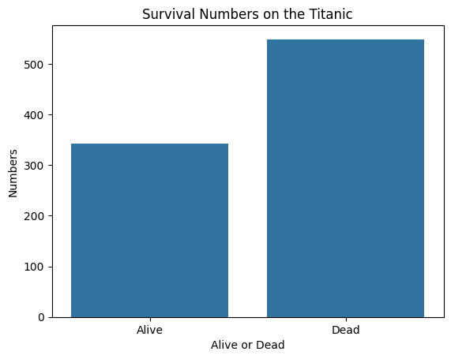

```python
# converting the survived column into a list
survived_list = titanic_df['Survived'].values.tolist()
print("Survived Numbers: ", survived_list)

# counting the number of people who survived and didn't
alive = 0
dead = 0

# for looping through the list of survivors
for i in range(0, len(survived_list)):
    if survived_list[i] == 0:
        dead += 1
    else:
        alive += 1

# printing out the values of people alive and dead
print("Alive: ", alive)
print("Dead: ", dead)

# creating a new list
survival_categories = ["Alive", "Dead"]
survial_numbers = [alive, dead]

# creating a bar plot
sns.barplot(x=survival_categories, y =survial_numbers)

# adding the title and labels
plt.title("Survival Numbers on the Titanic")
plt.xlabel("Alive or Dead")
plt.ylabel("Numbers")
```

We can also do this in an alternative manner, where we use Seaborn's **countplot** function.

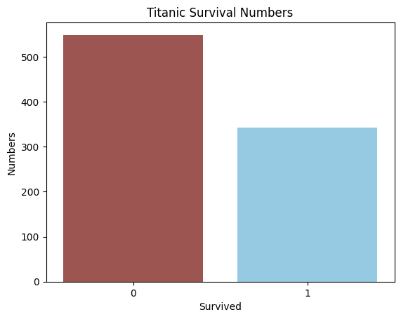

```python
# bar colors
bar_colors = {'0': '#AA4A44', '1':'#89CFF0'}

# counting the plot on a single categorical variable
sns.countplot(x='Survived', data=titanic_df, palette=bar_colors)

# labeling the axes and displaying the title
plt.title("Titanic Survival Numbers")
plt.ylabel("Numbers")

# displaying the plot
plt.show()
```

### Sources Used For Section Two

- https://www.kaggle.com/c/titanic/data
- https://stackoverflow.com/questions/45759966/counting-unique-values-in-a-column-in-pandas-dataframe-like-in-qlik
- https://stackoverflow.com/questions/54165508/convert-categorical-column-into-specific-integers
- https://pandas.pydata.org/docs/user_guide/categorical.html
- https://www.datacamp.com/tutorial/one-hot-encoding-python-tutorial
- https://www.geeksforgeeks.org/countplot-using-seaborn-in-python/
- https://seaborn.pydata.org/archive/0.11/generated/seaborn.countplot.html

## Section 3 | Missing Values

In this section, we have the variable Age that appears to have a number of **missing values** . In this section, we work on filling these missing values using the **mean, median and mode** . We then work on using a simple **supervised machine learning model (KNN)** to fill the missing values as a alternative method.

### Mean, Median & Mode

We start by creating **three** new columns in the data set labeled as `Age_fill_mean`, `Age_fill_median`, `Age_fill_mode` by copying the original **Age** variable.

```python
# viewing the titanic dataset
titanic_df.head(3)
```

|  | PassengerId | Survived | Pclass | Name | Sex | Age | SibSp | Parch | Ticket | Fare | Cabin | Embarked |
| --- | --- | --- | --- | --- | --- | --- | --- | --- | --- | --- | --- | --- |
| 0 | 1 | 0 | 3 | Braund, Mr. Owen Harris | male | 22.0 | 1 | 0 | A/5 21171 | 7.2500 | NaN | S |
| 1 | 2 | 1 | 1 | Cumings, Mrs. John Bradley (Florence Briggs Th... | female | 38.0 | 1 | 0 | PC 17599 | 71.2833 | C85 | C |
| 2 | 3 | 1 | 3 | Heikkinen, Miss. Laina | female | 26.0 | 0 | 0 | STON/O2. 3101282 | 7.9250 | NaN | S |

```python
# creating the mean, median and mode column headings
titanic_df['Age_fill_mean'] = titanic_df['Age']
titanic_df['Age_fill_median'] = titanic_df['Age']
titanic_df['Age_fill_mode'] = titanic_df['Age']

# checking for the presence of the columns
titanic_column_headings = ['Age_fill_mean', 'Age_fill_median', 'Age_fill_mode']
for column in titanic_column_headings:
    if column in titanic_df.columns:
        print(column, " is present")
```

```
Age_fill_mean  is present
Age_fill_median  is present
Age_fill_mode  is present
```

### Fill in Missing Values

Now that we have copied the `Age` column, we now need to work on filling out the **missing values** . Here are the following requirements:

- Fill the missing values in `Age_ﬁll_mean` with the mean `Age` in the data
- Fill the missing values in the `Age_fill_median` with the median `Age` in the data
- Fill the missing values in the `Age_fill_mode` with the mode `Age` in the data

```python
# filling out the missing with the mean, median and mode
titanic_df['Age_fill_mean'] = titanic_df['Age_fill_mean'].fillna(titanic_df['Age_fill_mean'].mean())
titanic_df['Age_fill_median'] = titanic_df['Age_fill_median'].fillna(titanic_df['Age_fill_median'].median())
titanic_df['Age_fill_mode'] = titanic_df['Age_fill_mode'].fillna(titanic_df['Age_fill_mode'].mode()[0])

# checking for any null values
mean_null =  titanic_df['Age_fill_mean'].isnull().any()
median_null = titanic_df['Age_fill_median'].isnull().any()
mode_null = titanic_df['Age_fill_mode'].isnull().any()

# printing out the null values
print("Mean: ", mean_null)
print("Median: ", median_null)
print("Mode: ", mode_null)

# checking the titanic dataset
titanic_df.head(3)
```

```
Mean:  False
Median:  False
Mode:  False
```

|  | PassengerId | Survived | Pclass | Name | Sex | Age | SibSp | Parch | Ticket | Fare | Cabin | Embarked | Age_fill_mean | Age_fill_median | Age_fill_mode |
| --- | --- | --- | --- | --- | --- | --- | --- | --- | --- | --- | --- | --- | --- | --- | --- |
| 0 | 1 | 0 | 3 | Braund, Mr. Owen Harris | male | 22.0 | 1 | 0 | A/5 21171 | 7.2500 | NaN | S | 22.0 | 22.0 | 22.0 |
| 1 | 2 | 1 | 1 | Cumings, Mrs. John Bradley (Florence Briggs Th... | female | 38.0 | 1 | 0 | PC 17599 | 71.2833 | C85 | C | 38.0 | 38.0 | 38.0 |
| 2 | 3 | 1 | 3 | Heikkinen, Miss. Laina | female | 26.0 | 0 | 0 | STON/O2. 3101282 | 7.9250 | NaN | S | 26.0 | 26.0 | 26.0 |

### Supervised Learning with KNN

We now move on to using a **supervised learning model (KNN)** to fill in the missing values. In order to accomplish this, we perform the **following** steps first:

1. Creating a new column in the data set called `Age_fill_knn`
2. Importing `KNeighborsRegressor` from `sklearn.neighbors`

```python
# creating a new column in the data set
titanic_df['Age_fill_knn'] = titanic_df['Age']

# importing the knn
from sklearn.neighbors import KNeighborsRegressor
```

Great! Now that we've created a new column and imported **KNeighborsRegressor** , we now need to divide our dataset into two datasets:

1. One called `data_drop_age_na` where there are no missing values for `Age`
2. One called `data_age_na` that contains all the rows with missing values for `Age`

```python
# new data frame where there are no missing values for age
data_drop_age_na = titanic_df[titanic_df['Age'].notna()]

# new dataframe where there are missing values for age
data_age_na = titanic_df[titanic_df['Age'].isna()]

# cross-checking the lengths
titanic_age_length = len(titanic_df['Age'])
drop_age_length = len(data_drop_age_na)
missing_age_length = len(data_age_na)

# using if condition to check if the length are equal
if titanic_age_length == (drop_age_length + missing_age_length):
    print("Valid!")
else:
    print("Not Valid!")

# viewing the dataframe for no missing values
print("No Missing Values for Age")
display(data_drop_age_na.head(3))
print("\n")

# viewing the dataframe for missing values
print("All the Rows with Missing Values")
display(data_age_na.head(3))
```

```
Valid!
No Missing Values for Age
```

|  | PassengerId | Survived | Pclass | Name | Sex | Age | SibSp | Parch | Ticket | Fare | Cabin | Embarked | Age_fill_mean | Age_fill_median | Age_fill_mode | Age_fill_knn |
| --- | --- | --- | --- | --- | --- | --- | --- | --- | --- | --- | --- | --- | --- | --- | --- | --- |
| 0 | 1 | 0 | 3 | Braund, Mr. Owen Harris | male | 22.0 | 1 | 0 | A/5 21171 | 7.2500 | NaN | S | 22.0 | 22.0 | 22.0 | 22.0 |
| 1 | 2 | 1 | 1 | Cumings, Mrs. John Bradley (Florence Briggs Th... | female | 38.0 | 1 | 0 | PC 17599 | 71.2833 | C85 | C | 38.0 | 38.0 | 38.0 | 38.0 |
| 2 | 3 | 1 | 3 | Heikkinen, Miss. Laina | female | 26.0 | 0 | 0 | STON/O2. 3101282 | 7.9250 | NaN | S | 26.0 | 26.0 | 26.0 | 26.0 |

```
All the Rows with Missing Values
```

|  | PassengerId | Survived | Pclass | Name | Sex | Age | SibSp | Parch | Ticket | Fare | Cabin | Embarked | Age_fill_mean | Age_fill_median | Age_fill_mode | Age_fill_knn |
| --- | --- | --- | --- | --- | --- | --- | --- | --- | --- | --- | --- | --- | --- | --- | --- | --- |
| 5 | 6 | 0 | 3 | Moran, Mr. James | male | NaN | 0 | 0 | 330877 | 8.4583 | NaN | Q | 29.699118 | 28.0 | 24.0 | NaN |
| 17 | 18 | 1 | 2 | Williams, Mr. Charles Eugene | male | NaN | 0 | 0 | 244373 | 13.0000 | NaN | S | 29.699118 | 28.0 | 24.0 | NaN |
| 19 | 20 | 1 | 3 | Masselmani, Mrs. Fatima | female | NaN | 0 | 0 | 2649 | 7.2250 | NaN | C | 29.699118 | 28.0 | 24.0 | NaN |

With the two datasets produced, we instantiate and fit a **KNN** model using `data_drop_age_na` where `n_neighbors` is set to 5, and the **features** used are `SibSp`, `Parch`, and `Fare`, and the response is `Age`. We then use this fitted model to **predict** in the `data_age_na` data frame.

```python
# the training dataset and the response variable
x_train = data_drop_age_na[['SibSp', 'Parch', 'Fare']]
y_train = data_drop_age_na['Age']

# the feature to predict
x_predict = data_age_na[['SibSp', 'Parch', 'Fare']]
```

```python
# instantiating the KNN model with 5 neighbors
titanic_knn = KNeighborsRegressor(n_neighbors=5)

# fitting the model with the training data
titanic_knn.fit(x_train, y_train)

# performing the predictions
age_predict = titanic_knn.predict(x_predict)

# printing out the results
print(age_predict)
print("Type: ", type(age_predict))
```

```
[24.8   32.7   32.5   32.5   27.8   30.8   21.584 30.9   21.4   30.8
 32.    30.    30.9   30.8   49.4   41.9   20.8   30.8   32.    23.8
 32.    32.    30.8   24.    30.2   32.    30.9   17.6   27.9   30.7
 27.6   37.    33.6   39.4   15.8   37.    29.2   45.4   30.    30.9
 30.9   37.    23.    30.8   15.8   25.8   25.9   30.    30.7   39.2
 30.9   30.9   42.    30.9   34.4   38.2   41.9   44.4   30.9   23.2
 31.    32.    28.    37.    23.2   40.4   30.8   26.4   49.4   32.5
 27.8   27.8   30.    21.4   30.9   34.2   30.8   21.8   15.8   30.8
 25.8   34.4   32.    30.8   30.7   30.9   26.4   30.8   28.4   32.
 39.6   30.9   32.    34.4   21.8   30.7   41.8   34.4   15.8   28.4
 32.    29.2   29.8   48.    32.    32.6   32.5   21.4   30.8   21.4
 22.8   32.    41.8   23.8   30.8   30.9   32.    32.    21.4   30.9
 25.9   27.2   32.    18.484 40.6   32.5   30.8   26.8   26.4   30.
 30.9   21.8   34.4   26.4   29.6   25.8   30.8   23.8   30.8   24.
 39.6   34.4   30.8   29.6   21.8   20.8   48.    37.2   21.8   34.4
 30.8   30.8   42.4   32.    37.4   30.2   32.5   30.9   21.8   26.8
 30.9   37.    44.4   34.4   31.    29.6   30.9   21.4   32.    42.4
 37.    39.8   21.4   37.    26.2   30.8   26.8  ]
Type:  <class 'numpy.ndarray'>
```

Next, we would like to check the total number of **missing** values in `Age_fill_knn` and cross check it with the number of values in the numpy array produced by our **KNN** model. This is to just check if the number of elements are the same on **both** sides.

```python
# finding the total number of elements including missing values
total_value_knn = len(titanic_df['Age_fill_knn'])
print("Total is: ", total_value_knn)

missing_value_knn = titanic_df['Age_fill_knn'].isna().sum()
print("Missing Values: ", missing_value_knn)

# finding the length of the numpy array
total_elements = age_predict.size
print("Total Elements of Numpy Array: ", total_elements)
```

```
Total is:  891
Missing Values:  177
Total Elements of Numpy Array:  177
```

Now that we have confirmed that both the missing values in the `age_fill_knn` and the number of values in the `age_predict` is the same, this means that we can go ahead and fill the missing values in the `age_fll_knn` from the numpy array.

```python
# boolean masking for missing values in age
missing_age_mask = titanic_df['Age_fill_knn'].isna()

# filling in missing values using the numpy array
titanic_df.loc[missing_age_mask, 'Age_fill_knn'] = age_predict

# checking the dataset again for missing values
new_missing_value_knn = titanic_df['Age_fill_knn'].isna().sum()
print("Missing Values: ", new_missing_value_knn)

# converting the pandas data frame into a .csv file for cross checking
titanic_df.to_csv("new_titanic.csv")
```

```
Missing Values:  0
```

Lastly, we would like to compare the results of the different methods of filling values using the mean, median, mode and using a supervised learning model (KNN). We achieve this using seaborn .

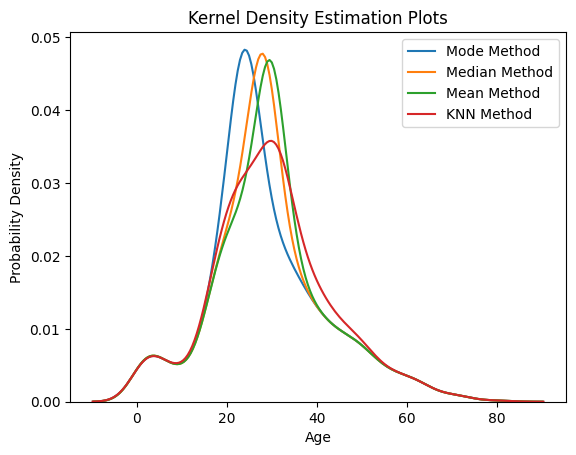

```python
# plotting the method of filling in the values using mode
sns.kdeplot(data=titanic_df['Age_fill_mode'], label="Mode Method")

# plotting the method of filling in the value using median
sns.kdeplot(data=titanic_df['Age_fill_median'], label="Median Method")

# plotting the method of filling in the value using mean
sns.kdeplot(data=titanic_df['Age_fill_mean'], label="Mean Method")

# plotting the method of filling in the value using knn
sns.kdeplot(data=titanic_df['Age_fill_knn'], label="KNN Method")

# setting the legend
plt.legend()

# setting the x and y axes and title
plt.title("Kernel Density Estimation Plots")
plt.xlabel("Age")
plt.ylabel("Probability Density")
```

### Sources Used For Section Three

- https://www.geeksforgeeks.org/adding-new-column-to-existing-dataframe-in-pandas/
- https://www.quora.com/How-do-you-check-if-a-column-has-a-null-value-in-Pandas
- https://www.datacamp.com/tutorial/k-nearest-neighbor-classification-scikit-learn